# TAZ-level Multiplier with regional variables

Simon Brewer Geography Department University of Utah

20 May, 2024

## Background

The overall goal is to estimate a multiplier representing the effects of transit on vehicle miles traveled (VMT). The multiplier is comprised of direct (`ADE`) and indirect (`AIE`) effects:

$$TM = (ADE + AIE) / ADE$$

## Regional variable

Data summary

| Name | dat$tpm |
| --- | --- |
| Number of rows | 6689 |
| Number of columns | 1 |
| _______________________ |  |
| Column type frequency: |  |
| numeric | 1 |
| ________________________ |  |
| Group variables | None |

**Variable type: numeric**

| skim_variable | n_missing | complete_rate | mean | sd | p0 | p25 | p50 | p75 | p100 | hist |
| --- | --- | --- | --- | --- | --- | --- | --- | --- | --- | --- |
| data | 0 | 1 | 5.39 | 0.67 | 3.92 | 5.29 | 5.61 | 5.61 | 6.42 | ▂▃▆▇▅ |

## Model paths

Ignoring confounders (to keep things simple) we can develop the following set of paths or structural equation model (we use `transit_acc` to represent accessibility and `act_den` to represent activity density). This is the directed acyclic graph (*DAG*) for the main components

A rough illustration of these given below:

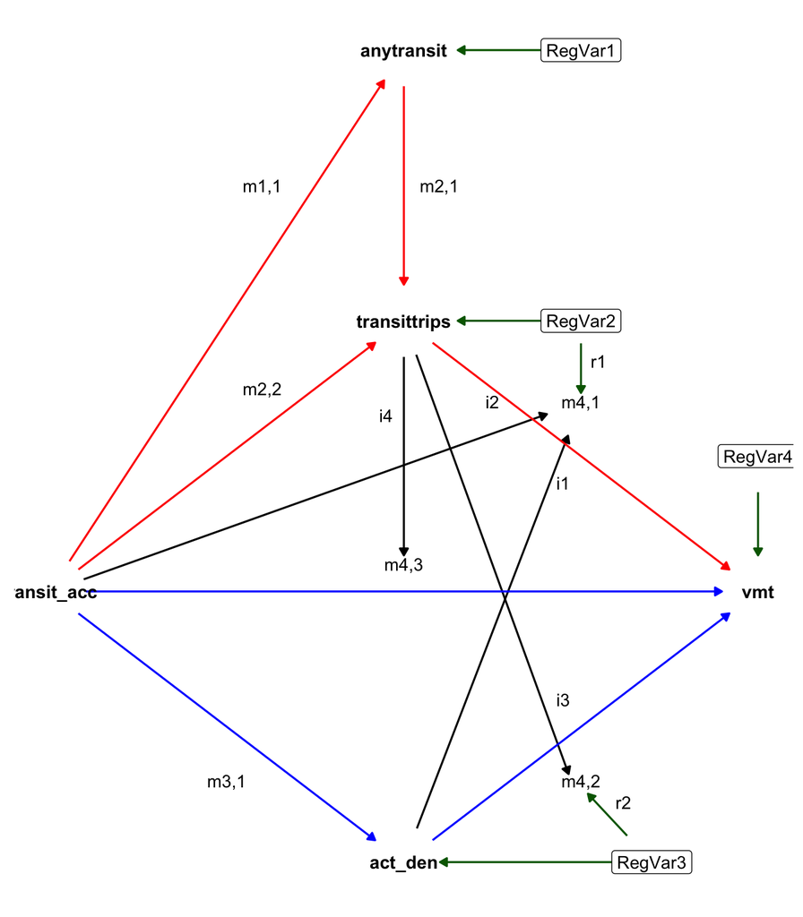

This shows that the basic multiplier is based on a set of direct and indirect paths:

- Direct effects
  - `transit accessibility` $\rightarrow \beta_{m1,1} \rightarrow$ `anytransit` $\rightarrow \beta_{m2,1} \rightarrow$ `transittrips` $\rightarrow \beta_{m4,1} \rightarrow$ `vmt`
  - `transit accessibility` $\rightarrow \beta_{m2,2} \rightarrow$ `transittrips` $\rightarrow \beta_{m4,1} \rightarrow$ `vmt`
- Indirect effects
  - `transit accessibility` $\rightarrow \beta_{m3,1} \rightarrow$ `activity density` $\rightarrow \beta_{4,2} \rightarrow$ `vmt`
  - `transit accessibility` $\rightarrow \beta_{m4,3} \rightarrow$ `vmt`

Where $\beta_{k,m}$ is the path coefficient from a regression model. From this we can estimate the two effects for the entire region:

- Direct:

$$\begin{aligned}
ADE & = (\beta_{m1,1} \times \beta_{m2,1} \times \beta_{m4,1}) +
(\beta_{m2,2} \times \beta_{m4,1})
\end{aligned}$$

- Indirect:

$$\begin{aligned}
AIE = (\beta_{m3,1} \times \beta_{m4,2}) + \beta_{m4,3}
\end{aligned}$$

To allow variations in the multiplier at the TAZ level, we need to include some interactions (or *moderators*) that will adjust coefficients and ultimately the multiplier for a given TAZ.

- `i1`: the effect of `transittrips` on `vmt` is moderated by activity density
- `i2`: the effect of `transittrips` on `vmt` is moderated by transit accessibility
- `i3`: the effect of activity density on `vmt` is moderated by `transittrips`
- `i4`: the effect of transit accessibility on `vmt` is moderated by `transittrips`
- `r1`: the effect of `transittrips` on `vmt` is moderated by regional population
- `r2`: the effect of activity density on `vmt` is moderated by regional population

And using these, we can update the equations to get TAZ-level direct and indirect effects that include regional variation:

- Direct:

$$\begin{split}
ADE = & (\beta_{m1,1} \times \beta_{m2,1} \times (\beta_{m4,1} + i_1
\cdot \mbox{actden} + i_2 \cdot \mbox{pctemp30t} + r_1 \cdot
\mbox{reg_var})) \: + \\
& (\beta_{m2,2} \times (\beta_{m4,1} + i_1 \cdot \mbox{actden} + i_2
\cdot \mbox{pctemp30t} + r_1 \cdot \mbox{reg_var}))
\end{split}$$

- Indirect:

$$\begin{split}
AIE = & (\beta_{m3,1} \times (\beta_{m4,2} + i_3 \cdot
\mbox{transittrips}) + r_2 \cdot \mbox{reg_var}) \: + \\
& (\beta_{m4,3} + i_4 \cdot \mbox{transittrips})
\end{split}$$

## Coefficients

### Path coefficients

```r
m11 = as.numeric(fixef(lm1)['pctemp30t'])
m21 = as.numeric(fixef(lm2)['anytransit'])
m22 = as.numeric(fixef(lm2)['pctemp30t'])
m41 = as.numeric(fixef(lm4)['transittrips'])
```

```r
m31 = as.numeric(fixef(lm3)['pctemp30t'])
m42 = as.numeric(fixef(lm4)['actden'])
m43 = as.numeric(fixef(lm4)['pctemp30t'])
```

```r
coef_df = data.frame(m11, m21, m22, m31, m41, m42, m43)
knitr::kable(coef_df)
```

| m11 | m21 | m22 | m31 | m41 | m42 | m43 |
| --- | --- | --- | --- | --- | --- | --- |
| 0.0032376 | 1.025186 | 0.0011087 | 0.2897973 | -6.812852 | -0.122598 | -0.1364594 |

### Interactions

```r
i1 <- as.numeric(fixef(lm4)['transittrips:actden'])
i2 <- as.numeric(fixef(lm4)['transittrips:pctemp30t'])
i3 <- as.numeric(fixef(lm4)['transittrips:actden'])
i4 <- as.numeric(fixef(lm4)['transittrips:pctemp30t'])
r1 <- as.numeric(fixef(lm4)['transittrips:reg_var'])
r2 <- as.numeric(fixef(lm4)['actden:reg_var'])
```

```r
int_df = data.frame(i1, i2, i3, i4, r1, r2)
knitr::kable(int_df)
```

| i1 | i2 | i3 | i4 | r1 | r2 |
| --- | --- | --- | --- | --- | --- |
| 0.0171529 | -0.0847876 | 0.0171529 | -0.0847876 | -0.390555 | 0.0290259 |

### Final direct effect equation

$$\begin{split}
ADE & = ({0.0032} \times {1.0252} \times ({-6.8129} + {0.0172} \cdot
\mbox{actden} + {-0.0848} \cdot \mbox{pctemp30t} + {-0.3906} \cdot
\mbox{reg_var})) \\
& + ({0.0011} \times ({-6.8129} + {0.0172} \cdot \mbox{actden} +
{-0.0848} \cdot \mbox{pctemp30t} + {-0.3906} \cdot \mbox{reg_var}))
\end{split}$$

### Final indirect effect equation

$$\begin{aligned}
AIE & = ({0.2898} \times ({-0.1226} + {0.0172} \cdot
\mbox{transittrips} + {0.029} \cdot \mbox{reg_var})) \\
& + ({-0.1365} + {-0.0848} \cdot \mbox{transittrips})
\end{aligned}$$

### TAZ Multipliers

- Direct effect

```r
ade = as.numeric((m11 * m21 * (m41 + i1 * dat$actden + i2 * dat$pctemp30t + r1 * dat$reg_var)) +
                   (m22 * (m41 + i1 * dat$actden + i2 * dat$pctemp30t + r1 * dat$reg_var)))
print(median(ade))
```

```
## [1] -0.02971535
```

- Indirect effect

```r
aie = as.numeric((m31 * (m42 + i3 * dat$transittrips + r2 * dat$reg_var)) + (m43 + i4 * dat$transittrips))
print(median(aie))
```

```
## [1] -0.1732456
```

- Multiplier

```r
TM = (ade + aie) / ade
print(range(TM))
```

```
## [1]  4.406496 24.839298
```

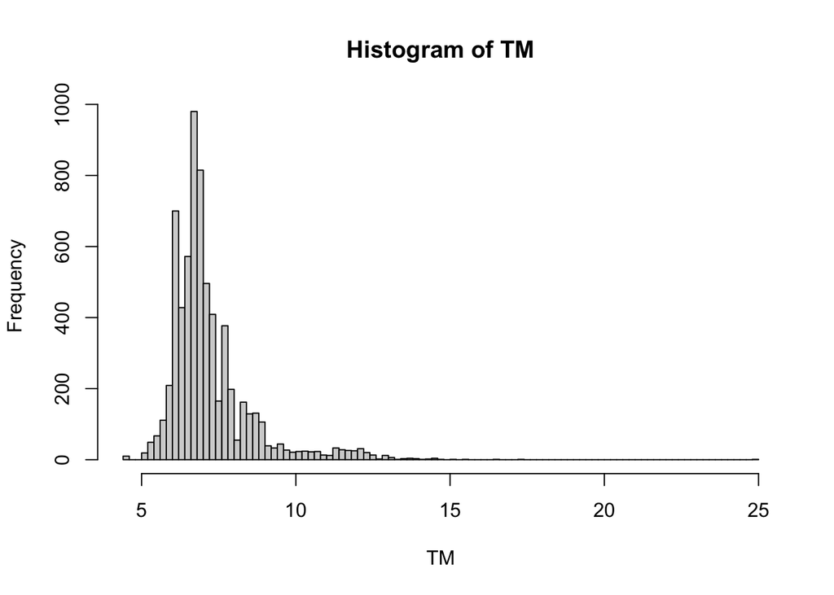

```r
#TM2 <- TM[TM < quantile(TM, 0.99)]
# TM2 <- TM[which(TM > 1)]
hist(TM, breaks = 100)
```

## Placetype Multiplier

```r
dat$TM = TM
dat_pt = dat %>%
  filter(PlaceType != "0")
```

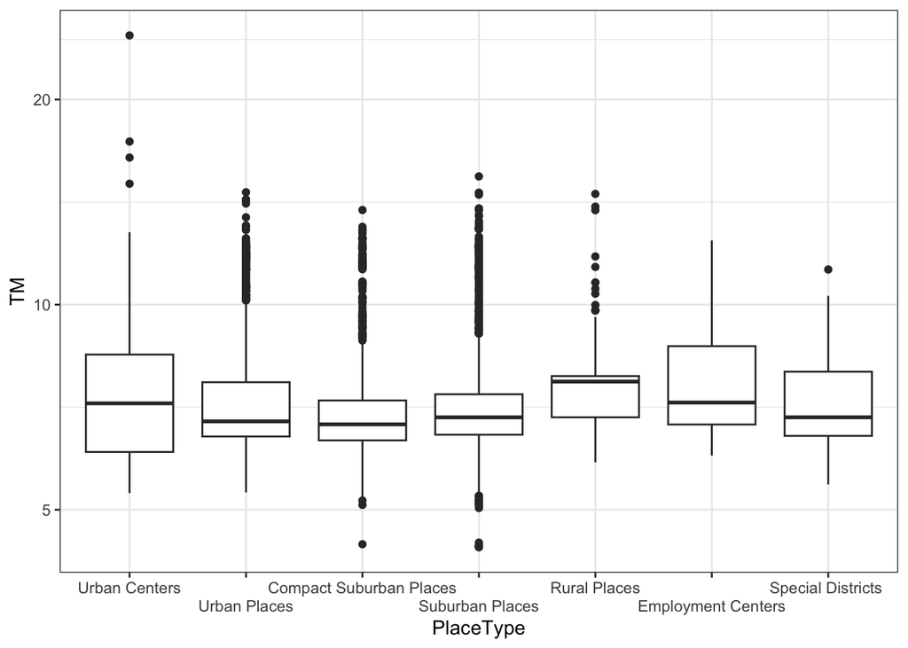

```r
ggplot(dat_pt, aes(x = PlaceType, y = TM)) +
         geom_boxplot() +
  scale_y_log10() +
  scale_x_discrete(guide = guide_axis(n.dodge = 2)) +
  theme_bw()
```

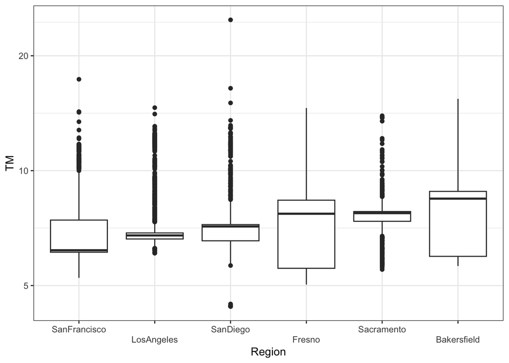

```r
ggplot(dat_pt, aes(x = reorder(region, TM, median), y = TM)) +
         geom_boxplot() +
  scale_y_log10() +
  scale_x_discrete("Region", guide = guide_axis(n.dodge = 2)) +
  theme_bw()
```

```r
dat_reg = dat_pt %>%
  group_by(PlaceType, region) %>%
  summarize(actden = mean(actden),
            pctemp30t = mean(pctemp30t),
            transittrips = mean(transittrips),
            reg_var = mean(reg_var))

ade = as.numeric((m11 * m21 *
                    (m41 + i1 * dat_reg$actden +
                       i2 * dat_reg$pctemp30t + r1 * dat_reg$reg_var)) +
                   (m22 * (m41 + i1 * dat_reg$actden +
                             i2 * dat_reg$pctemp30t +
                             r1 * dat_reg$reg_var)))

aie = as.numeric((m31 * (m42 + i3 * dat_reg$transittrips +
                           r2 * dat_reg$reg_var)) +
                   (m43 + i4 * dat_reg$transittrips))

dat_reg$TM = (ade + aie) / ade
```

```r
library(reshape2)
dat_reg_tab = dcast(dat_reg, region ~ PlaceType, value.var = "TM")
dat_reg_tab = dat_reg_tab %>%
  ungroup() %>%
  # mutate(Total = rowSums(across(where(is.numeric)))) %>%
  bind_rows(summarize(., region = "Mean",
                      across(where(is.numeric), \(x) mean(x, na.rm = TRUE))))

knitr::kable(dat_reg_tab)
```

| region | Urban Centers | Urban Places | Compact Suburban Places | Suburban Places | Rural Places | Employment Centers | Special Districts |
| --- | --- | --- | --- | --- | --- | --- | --- |
| Sacramento | 6.236269 | 6.787377 | 7.436598 | 7.613737 | 8.022589 | NA | 7.926019 |
| Fresno | 5.613721 | 5.300871 | 6.079137 | 6.894737 | 8.380704 | NA | NA |
| SanDiego | 8.469121 | 7.095004 | 7.142083 | 7.052131 | 7.215665 | 7.877346 | 7.056805 |
| SanFrancisco | 8.058281 | 7.751991 | 6.890467 | 6.635726 | 6.117790 | 6.631069 | 6.924451 |
| LosAngeles | 7.548705 | 7.430426 | 7.094492 | 6.977627 | 6.858117 | 7.729340 | 6.911022 |
| Bakersfield | 5.848996 | 6.907012 | 6.743778 | 7.153048 | 8.023909 | NA | 8.883270 |
| Mean | 6.962515 | 6.878780 | 6.897759 | 7.054501 | 7.436462 | 7.412585 | 7.540313 |

```r
dat_out <- dat %>%
  select(TAZ, region, region_id, regTAZ,
         pctemp30t, actden, transittrips,
         hhsize, incn, employed, entropy,
         pct4way, PlaceType, reg_var,
         taz_pop, taz_emp,
         TM)
write.csv(dat_out, "./output/multiplier_output.csv", row.names = FALSE)
```

```r
dat_out <- dat %>%
  select(TAZ, region, region_id, regTAZ,
         PlaceType,
         TM)
write.csv(dat_out, "./output/taz_multiplier_output.csv", row.names = FALSE)
```

### Regional Multiplier

- Direct effect

```r
ade = as.numeric((m11 * m21 * m41) + (m22 * m41))
print(median(ade))
```

```
## [1] -0.03016591
```

- Indirect effect

```r
aie = as.numeric((m31 * m42) + m43)
print(median(aie))
```

```
## [1] -0.171988
```

- Multiplier

```r
TM = (ade + aie) / ade
print(TM)
```

```
## [1] 6.701402
```

## Appendix 1: Models

### Model 1 `anytransit`

|  | anytransit |  |  |
| --- | --- | --- | --- |
| Predictors | Estimates | CI | p |
| (Intercept) | 0.1364 | 0.0633 – 0.2095 | **<0.001** |
| pctemp30t | 0.0032 | 0.0022 – 0.0042 | **<0.001** |
| hhsize | 0.0192 | 0.0097 – 0.0288 | **<0.001** |
| employed | 0.0084 | -0.0055 – 0.0223 | 0.234 |
| incn | -0.0002 | -0.0003 – 0.0000 | 0.077 |
| entropy | -0.0148 | -0.0472 – 0.0176 | 0.370 |
| pct4way | 0.0023 | 0.0019 – 0.0028 | **<0.001** |
| reg var | 0.0723 | 0.0205 – 0.1240 | **0.006** |
| Random Effects |  |  |  |
| σ<sup>2</sup> | 0.12 |  |  |
| τ<sub>00</sub> <sub>region</sub> | 0.01 |  |  |
| ICC | 0.05 |  |  |
| N <sub>region</sub> | 6 |  |  |
| Observations | 6689 |  |  |
| Marginal R<sup>2</sup> / Conditional R<sup>2</sup> | 0.057 / 0.103 |  |  |

### Model 2: `transittrips`

|  | transittrips |  |  |
| --- | --- | --- | --- |
| Predictors | Estimates | CI | p |
| (Intercept) | -0.0426 | -0.0854 – 0.0003 | 0.051 |
| pctemp30t | 0.0011 | 0.0004 – 0.0018 | **0.002** |
| hhsize | 0.0171 | 0.0102 – 0.0240 | **<0.001** |
| employed | -0.0009 | -0.0109 – 0.0092 | 0.866 |
| incn | -0.0004 | -0.0005 – -0.0002 | **<0.001** |
| entropy | -0.0046 | -0.0282 – 0.0189 | 0.700 |
| anytransit | 1.0252 | 1.0078 – 1.0425 | **<0.001** |
| reg var | 0.0124 | -0.0174 – 0.0422 | 0.414 |
| Random Effects |  |  |  |
| σ<sup>2</sup> | 0.07 |  |  |
| τ<sub>00</sub> <sub>region</sub> | 0.00 |  |  |
| ICC | 0.03 |  |  |
| N <sub>region</sub> | 6 |  |  |
| Observations | 6689 |  |  |
| Marginal R<sup>2</sup> / Conditional R<sup>2</sup> | 0.682 / 0.692 |  |  |

### Model 3: `actden`

|  | actden |  |  |
| --- | --- | --- | --- |
| Predictors | Estimates | CI | p |
| (Intercept) | -0.0224 | -2.2976 – 2.2528 | 0.985 |
| pctemp30t | 0.2898 | 0.2473 – 0.3323 | **<0.001** |
| entropy | -0.3146 | -1.6484 – 1.0192 | 0.644 |
| pct4way | 0.3191 | 0.2996 – 0.3386 | **<0.001** |
| pctemp30a | 0.0914 | 0.0704 – 0.1124 | **<0.001** |
| reg var | 5.6964 | 3.9877 – 7.4052 | **<0.001** |
| Random Effects |  |  |  |
| σ<sup>2</sup> | 212.19 |  |  |
| τ<sub>00</sub> <sub>region</sub> | 6.64 |  |  |
| ICC | 0.03 |  |  |
| N <sub>region</sub> | 6 |  |  |
| Observations | 6689 |  |  |
| Marginal R<sup>2</sup> / Conditional R<sup>2</sup> | 0.272 / 0.294 |  |  |

### Model 4: `vmt100occ`

|  | vmt100occ |  |  |
| --- | --- | --- | --- |
| Predictors | Estimates | CI | p |
| (Intercept) | 19.3365 | 17.1627 – 21.5104 | **<0.001** |
| hhsize | 5.7079 | 4.8916 – 6.5242 | **<0.001** |
| employed | 5.7347 | 4.5532 – 6.9163 | **<0.001** |
| incn | 0.0489 | 0.0344 – 0.0635 | **<0.001** |
| entropy | -3.9930 | -6.7295 – -1.2564 | **0.004** |
| pct4way | -0.0767 | -0.1199 – -0.0335 | **0.001** |
| transittrips | -6.8129 | -8.6320 – -4.9937 | **<0.001** |
| actden | -0.1226 | -0.1925 – -0.0527 | **0.001** |
| pctemp30t | -0.1365 | -0.2230 – -0.0500 | **0.002** |
| reg var | 0.2326 | -0.9476 – 1.4127 | 0.699 |
| transittrips × actden | 0.0172 | -0.0625 – 0.0968 | 0.673 |
| transittrips × pctemp30t | -0.0848 | -0.2719 – 0.1024 | 0.374 |
| actden × reg var | 0.0290 | -0.0264 – 0.0845 | 0.305 |
| transittrips × reg var | -0.3906 | -2.2949 – 1.5138 | 0.688 |
| Random Effects |  |  |  |
| σ<sup>2</sup> | 889.81 |  |  |
| τ<sub>00</sub> <sub>region</sub> | 1.09 |  |  |
| ICC | 0.00 |  |  |
| N <sub>region</sub> | 6 |  |  |
| Observations | 6689 |  |  |
| Marginal R<sup>2</sup> / Conditional R<sup>2</sup> | 0.136 / 0.137 |  |  |